# MCTOOLSR Presentation

Kunal Palawat

Load mctoolsr and associated packages. This package is used to understand microbial taxonomic data, similar to what John had presented last week. We are going to be making heat maps and ordination graphs today.

```r
#install.packages("devtools")
#devtools::install_github("leffj/mctoolsr")
library(mctoolsr)
```

```r
library(ggplot2)
```

The first step is to load in data. These lines bring in data from one of the developpers and format it so that we can use the rest of the functions properly.

```r
tax_table_fp = system.file('extdata', 'fruits_veggies_taxa_table_wTax.biom',
                           package = 'mctoolsr')
map_fp = system.file('extdata', 'fruits_veggies_metadata.txt',
                     package = 'mctoolsr')
input = load_taxa_table(tab_fp = tax_table_fp,
                        map_fp = map_fp)
```

```
## 32 samples loaded
```

This code rarefies the data.This means to randomly select a specified number of observations from each sample. In this case we are going to find the minimum number of observations in any of our samples and use that number. Also shown is the structure of the data.

```r
input_rar = single_rarefy(input = input,
                          depth = min(colSums(input$data_loaded)))
```

```
## 32 samples remaining
```

```r
names(input_rar)
```

```
## [1] "data_loaded"     "map_loaded"      "taxonomy_loaded"
```

```r
head(input_rar$data_loaded)
```

```
##        ProA12 ProA13 ProA14 ProA15 ProA16 ProA33 ProA34 ProA35 ProA36
## OTU_2       0      0      0      0      0      0      0      0      2
## OTU_20      1      0      0      0      0      0      0      0      0
## OTU_27      0      0      0      0      0      0      0      0      0
## OTU_29      0      0      0      1      0      0      0      0      0
## OTU_32      1      0      0      0      0      0      0      0      2
## OTU_49      0      0      0      0      0      0      0      0      0
##        ProA37 ProA58 ProA65 ProA66 ProB10 ProB12 ProB33 ProB34 ProB35
## OTU_2       0      0      0      0      0      0      0      0      0
## OTU_20      0      0      0      0      0      0      0      0      0
## OTU_27      0      0      0      0      0      0      0      1      0
## OTU_29      0      0      0      0      0      0      0      0      0
## OTU_32      0      0      0      0      0      0      0      0      0
## OTU_49      0      0      0      0      0      0      1      0      0
##        ProB36 ProB39 ProB40 ProB57 ProB58 ProB60 ProB67 ProB70 ProB71
## OTU_2       0      0      0      0      0      0      0      0      0
## OTU_20      0      0      0      0      0      0      0      0      0
## OTU_27      0      0      0      0      0      0      0      0      0
## OTU_29      0      0      0      0      0      0      0      0      0
## OTU_32      0      0      0      0      0      0      0      0      0
## OTU_49      0      0      0      0      0      0      0      0      0
##        ProB9 ProC36 ProC40 ProC65 ProC66
## OTU_2      0      0      0      0      0
## OTU_20     1      0      0      0      0
## OTU_27     0      1      0      0      0
## OTU_29     0      0      0      0      0
## OTU_32     0      0      0      0      0
## OTU_49     0      4      0      0      0
```

```r
head(input_rar$map_loaded)
```

```
##         Sample_type    Farm_type            Sample_Farming
## ProA12    Mushrooms Conventional    Mushrooms_Conventional
## ProA13    Mushrooms      Organic         Mushrooms_Organic
## ProA14    Mushrooms      Organic         Mushrooms_Organic
## ProA15    Mushrooms      Organic         Mushrooms_Organic
## ProA16    Mushrooms      Organic         Mushrooms_Organic
## ProA33 Strawberries Conventional Strawberries_Conventional
```

```r
head(input_rar$taxonomy_loaded)
```

```
##          taxonomy1         taxonomy2              taxonomy3
## OTU_2  k__Bacteria p__Actinobacteria      c__Actinobacteria
## OTU_20 k__Bacteria p__Proteobacteria c__Gammaproteobacteria
## OTU_27 k__Bacteria p__Proteobacteria  c__Betaproteobacteria
## OTU_29 k__Bacteria  p__Bacteroidetes    c__Sphingobacteriia
## OTU_32 k__Bacteria p__Proteobacteria  c__Betaproteobacteria
## OTU_49 k__Bacteria     p__Firmicutes             c__Bacilli
##                    taxonomy4              taxonomy5        taxonomy6
## OTU_2     o__Actinomycetales  f__Pseudonocardiaceae g__Amycolatopsis
## OTU_20      o__Aeromonadales      f__Aeromonadaceae              g__
## OTU_27    o__Burkholderiales    f__Oxalobacteraceae     unclassified
## OTU_29 o__Sphingobacteriales f__Sphingobacteriaceae    g__Pedobacter
## OTU_32    o__Burkholderiales    f__Oxalobacteraceae              g__
## OTU_49         o__Bacillales         f__Bacillaceae              g__
##           taxonomy7
## OTU_2           s__
## OTU_20          s__
## OTU_27 unclassified
## OTU_29          s__
## OTU_32          s__
## OTU_49          s__
```

This code calculates diversity indecies for the data. If you use the function “diversity()” you can export the index values by writing it into a .csv file.

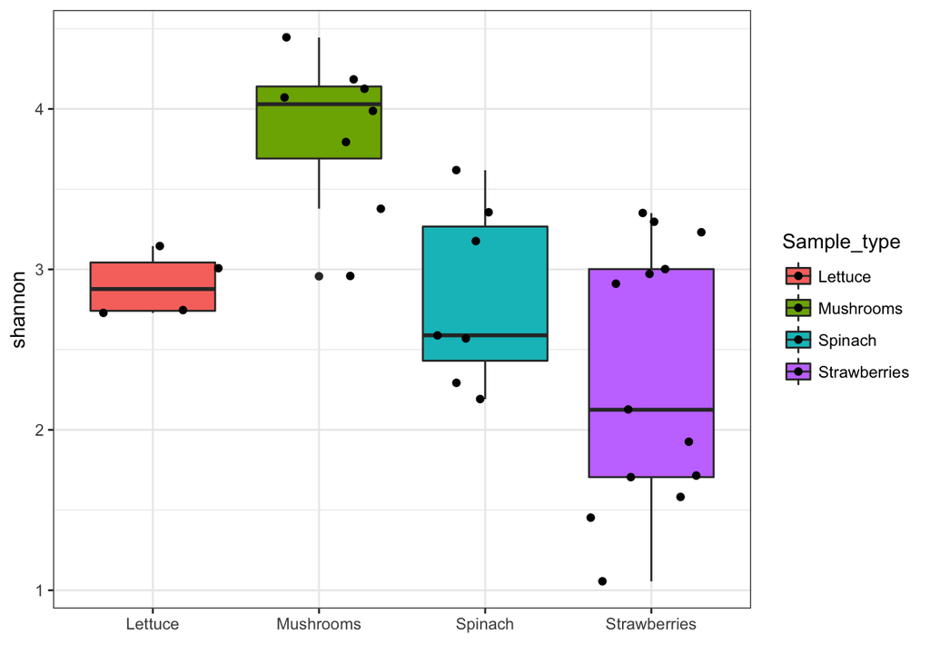

```r
plot_diversity(input = input_rar,
               variable = 'Sample_type',
               metric = 'shannon') +
  geom_jitter()
```

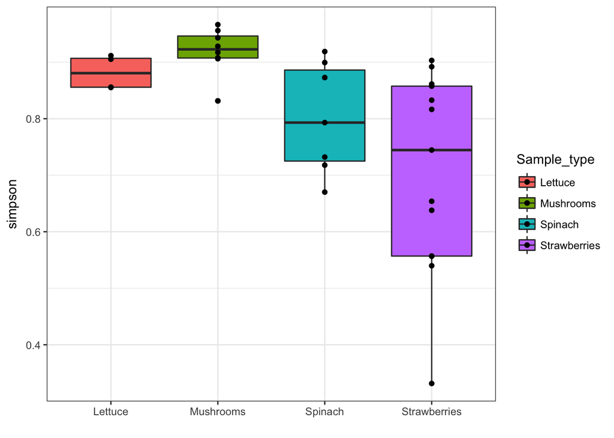

```r
plot_diversity(input = input_rar,
               variable = 'Sample_type',
               metric = 'simpson') +
  geom_point()
```

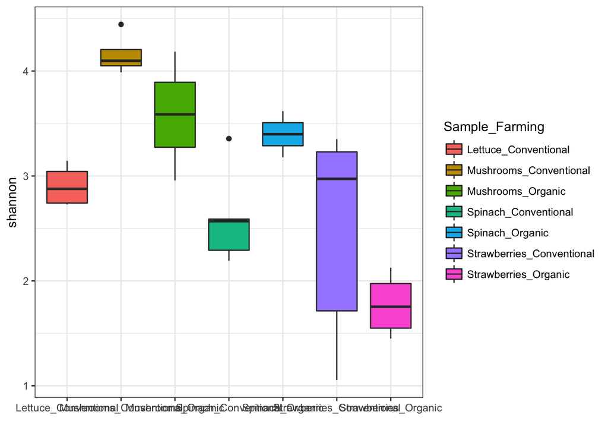

```r
plot_diversity(input = input_rar,
               variable = 'Sample_Farming',
               metric = 'shannon')
```

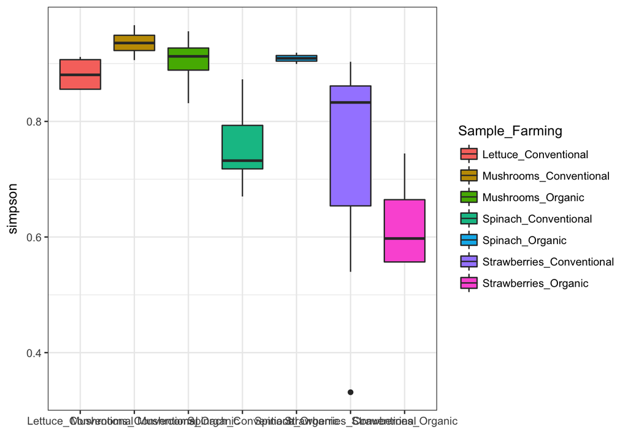

```r
plot_diversity(input = input_rar,
               variable = 'Sample_Farming',
               metric = 'simpson')
```

```r
tax_sum_phyla = summarize_taxonomy(input=input_rar,
                                   level = 2,
                                   report_higher_tax = FALSE)
head(tax_sum_phyla)
```

```
##                          ProA12       ProA13      ProA14      ProA15
## p__                0.0009910803 0.0000000000 0.000000000 0.000000000
## p__[Thermi]        0.0009910803 0.0000000000 0.000000000 0.000000000
## p__Acidobacteria   0.0009910803 0.0000000000 0.000000000 0.000000000
## p__Actinobacteria  0.3924677899 0.0118929633 0.003964321 0.016848365
## p__Armatimonadetes 0.0000000000 0.0009910803 0.000000000 0.004955401
## p__Bacteroidetes   0.0901883053 0.5193260654 0.783944500 0.382556987
##                         ProA16      ProA33       ProA34      ProA35
## p__                0.000000000 0.000000000 0.0000000000 0.000000000
## p__[Thermi]        0.000000000 0.000000000 0.0049554014 0.000000000
## p__Acidobacteria   0.000000000 0.000000000 0.0000000000 0.000000000
## p__Actinobacteria  0.003964321 0.052527255 0.0743310208 0.088206145
## p__Armatimonadetes 0.000000000 0.000000000 0.0000000000 0.000000000
## p__Bacteroidetes   0.591674926 0.004955401 0.0009910803 0.001982161
##                         ProA36      ProA37      ProA58      ProA65
## p__                0.000000000 0.000000000 0.000000000 0.000000000
## p__[Thermi]        0.003964321 0.000000000 0.000000000 0.000000000
## p__Acidobacteria   0.000000000 0.000000000 0.000000000 0.000000000
## p__Actinobacteria  0.030723489 0.002973241 0.000000000 0.004955401
## p__Armatimonadetes 0.000000000 0.000000000 0.000000000 0.000000000
## p__Bacteroidetes   0.006937562 0.006937562 0.002973241 0.004955401
##                          ProA66     ProB10     ProB12      ProB33
## p__                0.0000000000 0.00000000 0.00000000 0.000000000
## p__[Thermi]        0.0009910803 0.00000000 0.00000000 0.000000000
## p__Acidobacteria   0.0000000000 0.00000000 0.00000000 0.000000000
## p__Actinobacteria  0.0039643211 0.01883053 0.01189296 0.009910803
## p__Armatimonadetes 0.0000000000 0.00000000 0.00000000 0.000000000
## p__Bacteroidetes   0.0059464817 0.36669970 0.46580773 0.010901883
##                          ProB34      ProB35      ProB36      ProB39
## p__                0.0000000000 0.000000000 0.000000000 0.000000000
## p__[Thermi]        0.0009910803 0.000000000 0.000000000 0.000000000
## p__Acidobacteria   0.0000000000 0.000000000 0.000000000 0.000000000
## p__Actinobacteria  0.0049554014 0.003964321 0.002973241 0.006937562
## p__Armatimonadetes 0.0000000000 0.000000000 0.000000000 0.000000000
## p__Bacteroidetes   0.0009910803 0.000000000 0.000000000 0.012884044
##                          ProB40       ProB57 ProB58       ProB60
## p__                0.0000000000 0.0000000000      0 0.0000000000
## p__[Thermi]        0.0000000000 0.0000000000      0 0.0000000000
## p__Acidobacteria   0.0000000000 0.0000000000      0 0.0000000000
## p__Actinobacteria  0.0019821606 0.0009910803      0 0.0009910803
## p__Armatimonadetes 0.0000000000 0.0000000000      0 0.0000000000
## p__Bacteroidetes   0.0009910803 0.0009910803      0 0.0009910803
##                         ProB67       ProB70      ProB71       ProB9
## p__                0.000000000 0.0000000000 0.000000000 0.000000000
## p__[Thermi]        0.000000000 0.0000000000 0.000000000 0.000000000
## p__Acidobacteria   0.000000000 0.0009910803 0.000000000 0.000000000
## p__Actinobacteria  0.002973241 0.0178394450 0.007928642 0.008919722
## p__Armatimonadetes 0.000000000 0.0000000000 0.000000000 0.000000000
## p__Bacteroidetes   0.017839445 0.0099108028 0.011892963 0.195242815
##                         ProC36       ProC40      ProC65       ProC66
## p__                0.000000000 0.0000000000 0.000000000 0.0000000000
## p__[Thermi]        0.000000000 0.0009910803 0.000000000 0.0009910803
## p__Acidobacteria   0.000000000 0.0009910803 0.000000000 0.0000000000
## p__Actinobacteria  0.058473736 0.0247770069 0.003964321 0.0059464817
## p__Armatimonadetes 0.000000000 0.0000000000 0.000000000 0.0000000000
## p__Bacteroidetes   0.007928642 0.0029732408 0.000000000 0.0009910803
```

```r
tax_sum_class = summarize_taxonomy(input=input_rar,
                                   level = 3,
                                   report_higher_tax = TRUE)
head(tax_sum_class)
```

```
##                                                         ProA12     ProA13
## k__Bacteria; p__; c__                             0.0009910803 0.00000000
## k__Bacteria; p__[Thermi]; c__Deinococci           0.0009910803 0.00000000
## k__Bacteria; p__Acidobacteria; c__iii1-8          0.0009910803 0.00000000
## k__Bacteria; p__Acidobacteria; c__Solibacteres    0.0000000000 0.00000000
## k__Bacteria; p__Actinobacteria; c__Acidimicrobiia 0.0000000000 0.00000000
## k__Bacteria; p__Actinobacteria; c__Actinobacteria 0.3924677899 0.01189296
##                                                        ProA14     ProA15
## k__Bacteria; p__; c__                             0.000000000 0.00000000
## k__Bacteria; p__[Thermi]; c__Deinococci           0.000000000 0.00000000
## k__Bacteria; p__Acidobacteria; c__iii1-8          0.000000000 0.00000000
## k__Bacteria; p__Acidobacteria; c__Solibacteres    0.000000000 0.00000000
## k__Bacteria; p__Actinobacteria; c__Acidimicrobiia 0.000000000 0.00000000
## k__Bacteria; p__Actinobacteria; c__Actinobacteria 0.003964321 0.01684836
##                                                        ProA16     ProA33
## k__Bacteria; p__; c__                             0.000000000 0.00000000
## k__Bacteria; p__[Thermi]; c__Deinococci           0.000000000 0.00000000
## k__Bacteria; p__Acidobacteria; c__iii1-8          0.000000000 0.00000000
## k__Bacteria; p__Acidobacteria; c__Solibacteres    0.000000000 0.00000000
## k__Bacteria; p__Actinobacteria; c__Acidimicrobiia 0.000000000 0.00000000
## k__Bacteria; p__Actinobacteria; c__Actinobacteria 0.002973241 0.05153617
##                                                        ProA34     ProA35
## k__Bacteria; p__; c__                             0.000000000 0.00000000
## k__Bacteria; p__[Thermi]; c__Deinococci           0.004955401 0.00000000
## k__Bacteria; p__Acidobacteria; c__iii1-8          0.000000000 0.00000000
## k__Bacteria; p__Acidobacteria; c__Solibacteres    0.000000000 0.00000000
## k__Bacteria; p__Actinobacteria; c__Acidimicrobiia 0.001982161 0.00000000
## k__Bacteria; p__Actinobacteria; c__Actinobacteria 0.071357780 0.08721506
##                                                        ProA36      ProA37
## k__Bacteria; p__; c__                             0.000000000 0.000000000
## k__Bacteria; p__[Thermi]; c__Deinococci           0.003964321 0.000000000
## k__Bacteria; p__Acidobacteria; c__iii1-8          0.000000000 0.000000000
## k__Bacteria; p__Acidobacteria; c__Solibacteres    0.000000000 0.000000000
## k__Bacteria; p__Actinobacteria; c__Acidimicrobiia 0.000000000 0.000000000
## k__Bacteria; p__Actinobacteria; c__Actinobacteria 0.029732408 0.002973241
##                                                   ProA58      ProA65
## k__Bacteria; p__; c__                                  0 0.000000000
## k__Bacteria; p__[Thermi]; c__Deinococci                0 0.000000000
## k__Bacteria; p__Acidobacteria; c__iii1-8               0 0.000000000
## k__Bacteria; p__Acidobacteria; c__Solibacteres         0 0.000000000
```

[output cut: 64 more lines]

```
## k__Bacteria; p__Actinobacteria; c__Actinobacteria 0.005946482 0.052527255
##                                                         ProC40      ProC65
## k__Bacteria; p__; c__                             0.0000000000 0.000000000
## k__Bacteria; p__[Thermi]; c__Deinococci           0.0009910803 0.000000000
## k__Bacteria; p__Acidobacteria; c__iii1-8          0.0000000000 0.000000000
## k__Bacteria; p__Acidobacteria; c__Solibacteres    0.0009910803 0.000000000
## k__Bacteria; p__Actinobacteria; c__Acidimicrobiia 0.0000000000 0.000000000
## k__Bacteria; p__Actinobacteria; c__Actinobacteria 0.0198216056 0.003964321
##                                                         ProC66
## k__Bacteria; p__; c__                             0.0000000000
## k__Bacteria; p__[Thermi]; c__Deinococci           0.0009910803
## k__Bacteria; p__Acidobacteria; c__iii1-8          0.0000000000
## k__Bacteria; p__Acidobacteria; c__Solibacteres    0.0000000000
## k__Bacteria; p__Actinobacteria; c__Acidimicrobiia 0.0000000000
## k__Bacteria; p__Actinobacteria; c__Actinobacteria 0.0059464817
```

```r
tax_sum_family = summarize_taxonomy(input=input_rar,
                                   level = 5,
                                   report_higher_tax = FALSE)
head(tax_sum_family)
```

```
##                             ProA12       ProA13       ProA14       ProA15
## f__                    0.025768087 0.0069375619 0.0009910803 0.0376610505
## f__[Chromatiaceae]     0.001982161 0.0000000000 0.0000000000 0.0009910803
## f__[Exiguobacteraceae] 0.050545094 0.0009910803 0.0000000000 0.0000000000
## f__[Fimbriimonadaceae] 0.000000000 0.0009910803 0.0000000000 0.0039643211
## f__[Tissierellaceae]   0.000000000 0.0000000000 0.0000000000 0.0000000000
## f__[Weeksellaceae]     0.010901883 0.0802775025 0.4568880079 0.0059464817
##                              ProA16       ProA33      ProA34      ProA35
## f__                    0.0009910803 0.0158572844 0.006937562 0.001982161
## f__[Chromatiaceae]     0.0000000000 0.0000000000 0.000000000 0.000000000
## f__[Exiguobacteraceae] 0.0000000000 0.0000000000 0.000000000 0.000000000
## f__[Fimbriimonadaceae] 0.0000000000 0.0000000000 0.000000000 0.000000000
## f__[Tissierellaceae]   0.0000000000 0.0000000000 0.000000000 0.000000000
## f__[Weeksellaceae]     0.1754212091 0.0009910803 0.000000000 0.000000000
##                              ProA36 ProA37 ProA58       ProA65      ProA66
## f__                    0.0039643211      0      0 0.0009910803 0.001982161
## f__[Chromatiaceae]     0.0000000000      0      0 0.0000000000 0.000000000
## f__[Exiguobacteraceae] 0.0000000000      0      0 0.0455896928 0.064420218
## f__[Fimbriimonadaceae] 0.0000000000      0      0 0.0000000000 0.000000000
## f__[Tissierellaceae]   0.0000000000      0      0 0.0000000000 0.000000000
## f__[Weeksellaceae]     0.0009910803      0      0 0.0009910803 0.000000000
##                             ProB10      ProB12      ProB33       ProB34
## f__                    0.014866204 0.004955401 0.000000000 0.0019821606
## f__[Chromatiaceae]     0.007928642 0.052527255 0.000000000 0.0000000000
## f__[Exiguobacteraceae] 0.009910803 0.009910803 0.000000000 0.0000000000
## f__[Fimbriimonadaceae] 0.000000000 0.000000000 0.000000000 0.0000000000
## f__[Tissierellaceae]   0.000000000 0.000000000 0.000000000 0.0000000000
## f__[Weeksellaceae]     0.094152626 0.010901883 0.004955401 0.0009910803
##                             ProB35 ProB36      ProB39 ProB40       ProB57
## f__                    0.001982161      0 0.001982161      0 0.0000000000
## f__[Chromatiaceae]     0.000000000      0 0.000000000      0 0.0000000000
## f__[Exiguobacteraceae] 0.000000000      0 0.000000000      0 0.0019821606
## f__[Fimbriimonadaceae] 0.000000000      0 0.000000000      0 0.0000000000
## f__[Tissierellaceae]   0.000000000      0 0.001982161      0 0.0000000000
## f__[Weeksellaceae]     0.000000000      0 0.012884044      0 0.0009910803
##                        ProB58       ProB60      ProB67      ProB70
## f__                         0 0.0000000000 0.000000000 0.005946482
## f__[Chromatiaceae]          0 0.0000000000 0.000000000 0.000000000
## f__[Exiguobacteraceae]      0 0.0019821606 0.028741328 0.056491576
## f__[Fimbriimonadaceae]      0 0.0000000000 0.000000000 0.000000000
## f__[Tissierellaceae]        0 0.0000000000 0.000000000 0.000000000
## f__[Weeksellaceae]          0 0.0009910803 0.003964321 0.004955401
##                              ProB71        ProB9      ProC36      ProC40
## f__                    0.0009910803 0.0089197225 0.019821606 0.002973241
## f__[Chromatiaceae]     0.0000000000 0.0227948464 0.000000000 0.000000000
## f__[Exiguobacteraceae] 0.0436075322 0.0654112983 0.001982161 0.000000000
## f__[Fimbriimonadaceae] 0.0000000000 0.0000000000 0.000000000 0.000000000
## f__[Tissierellaceae]   0.0000000000 0.0009910803 0.000000000 0.000000000
## f__[Weeksellaceae]     0.0049554014 0.0218037661 0.000000000 0.000000000
##                             ProC65       ProC66
## f__                    0.000000000 0.0000000000
## f__[Chromatiaceae]     0.000000000 0.0000000000
## f__[Exiguobacteraceae] 0.003964321 0.0019821606
## f__[Fimbriimonadaceae] 0.000000000 0.0000000000
## f__[Tissierellaceae]   0.000000000 0.0000000000
## f__[Weeksellaceae]     0.000000000 0.0009910803
```

An easier way to see this information is via a heat map. This package also allows us to separate the data based on our treatments.

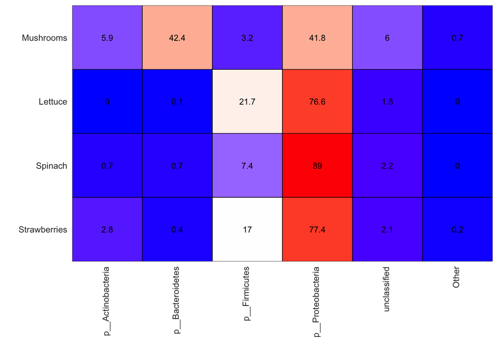

```r
plot_ts_heatmap(tax_table = tax_sum_phyla,
                metadata_map = input_rar$map_loaded,
                min_rel_abund = 0.01,
                type_header = 'Sample_type',
                custom_sample_order = c('Mushrooms', 'Lettuce', 'Spinach', 'Strawberries'))
```

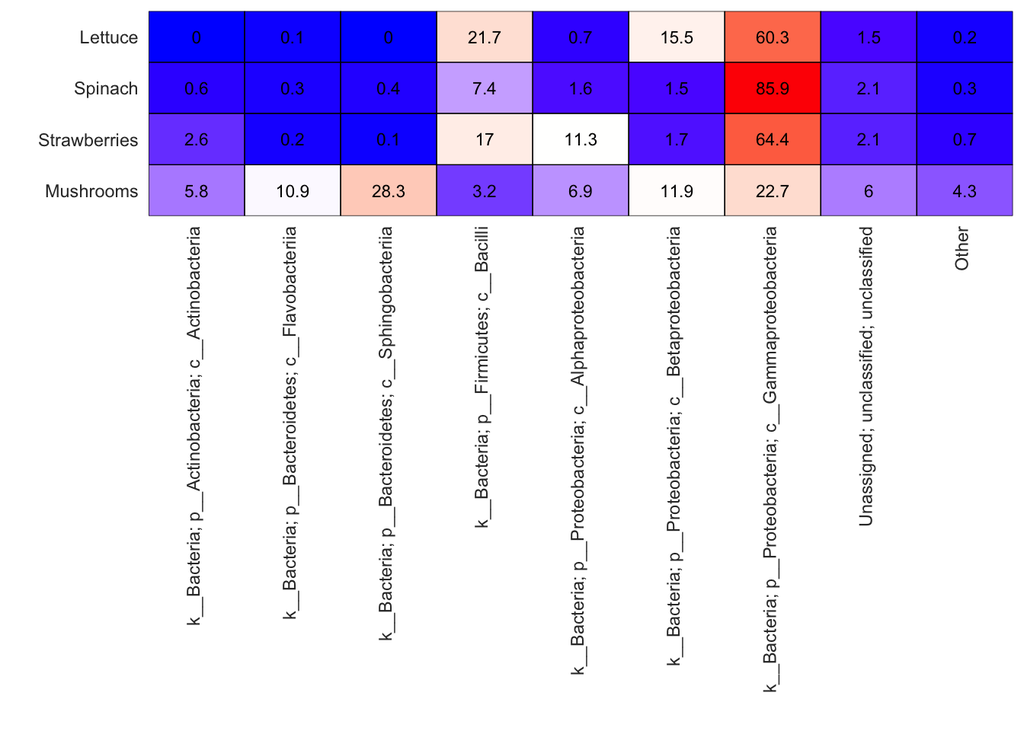

```r
plot_ts_heatmap(tax_table = tax_sum_class,
                metadata_map = input_rar$map_loaded,
                min_rel_abund = 0.01,
                type_header = 'Sample_type',
                custom_sample_order = c('Lettuce', 'Spinach', 'Strawberries', 'Mushrooms'))
```

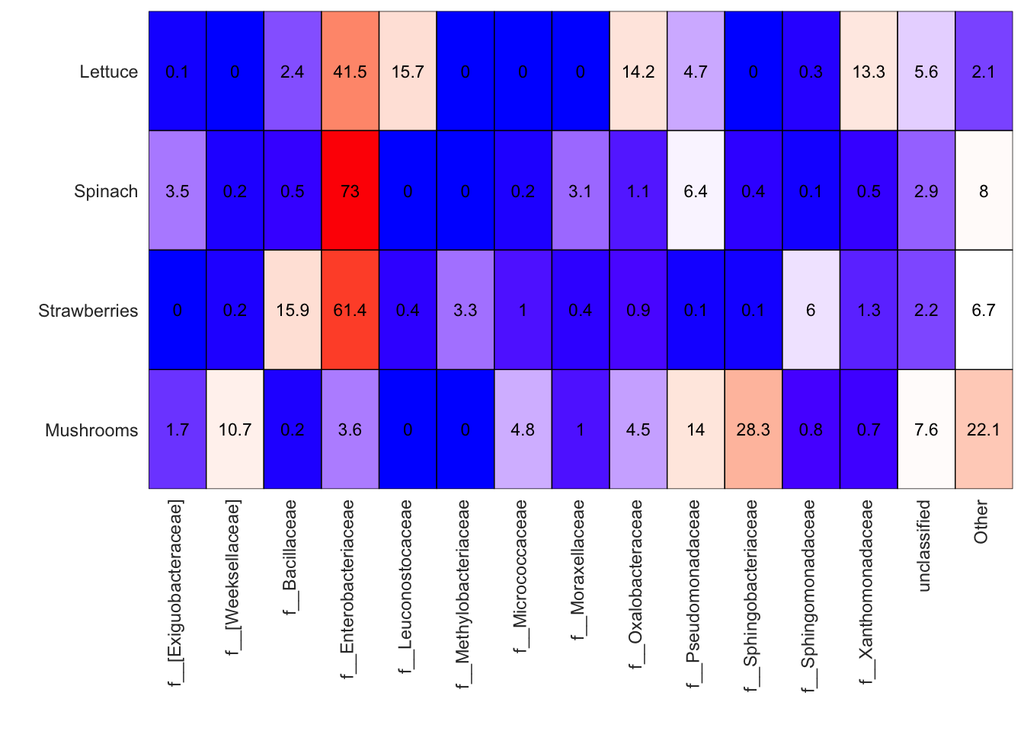

```r
plot_ts_heatmap(tax_table = tax_sum_family,
                metadata_map = input_rar$map_loaded,
                min_rel_abund = 0.01,
                type_header = 'Sample_type',
                custom_sample_order = c('Lettuce', 'Spinach', 'Strawberries', 'Mushrooms'))
```

Next we will calculate a dissimilarity matrix and plot an ordination quickly. This graph shows us how different the communities in our treatments are.

```
## *** Solution reached
```

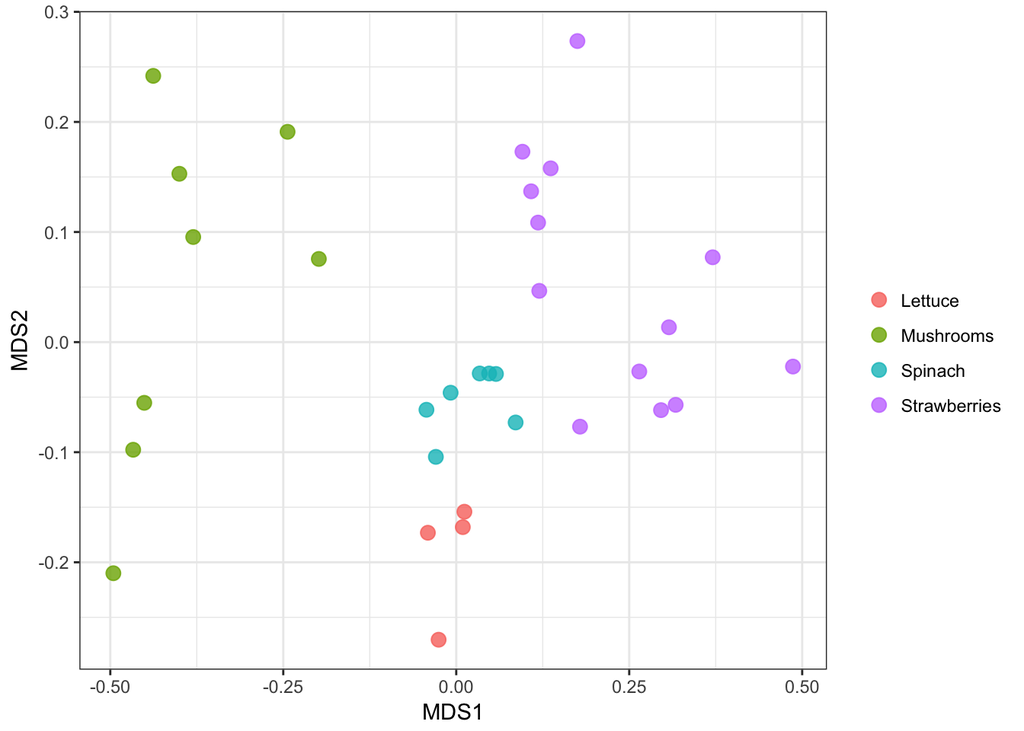

```r
dissMatrix <- calc_dm(input_rar$data_loaded)
plot_nmds(dm=dissMatrix,
          metadata_map = input_rar$map_loaded,
          color_cat = "Sample_type")
```

```
## *** Solution reached
```

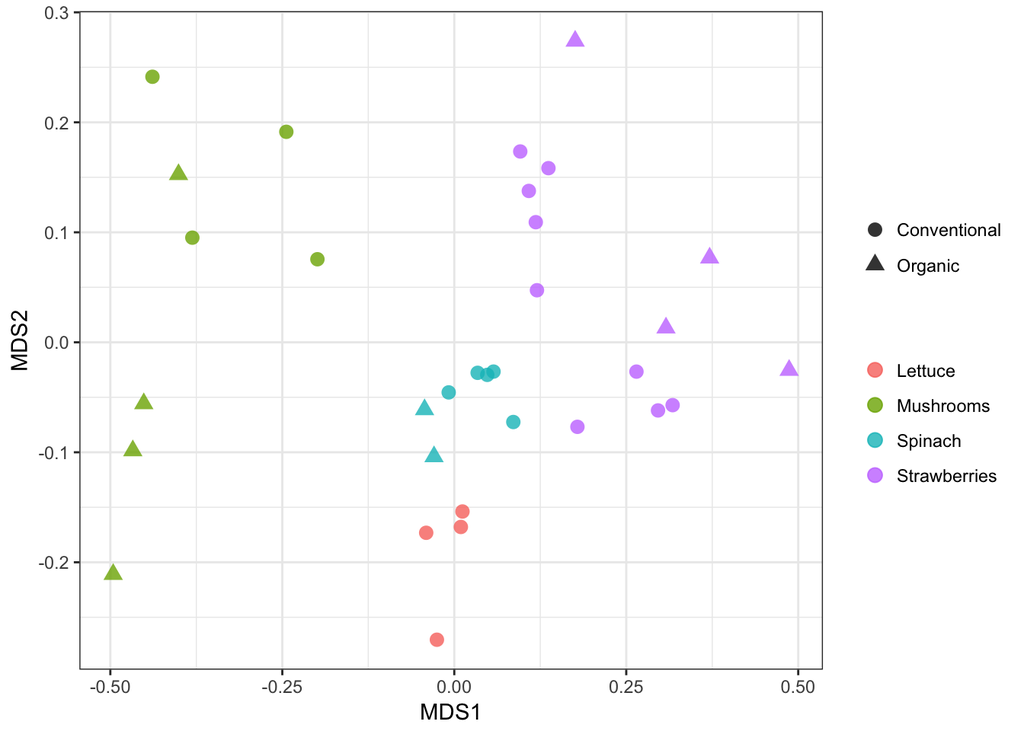

```r
plot_nmds(dm=dissMatrix,
          metadata_map = input_rar$map_loaded,
          color_cat = "Sample_type",
          shape_cat = "Farm_type")
```

This is how to have more control over the ordination.

```r
ordination <- calc_ordination(dissMatrix, "nmds")
```

```
## *** Solution reached
```

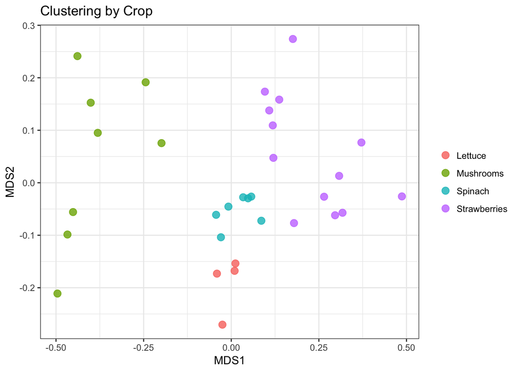

```r
plot_ordination(input = input_rar,
                ordination_axes = ordination,
                color_cat = 'Sample_type')+
  ggtitle("Clustering by Crop")
```

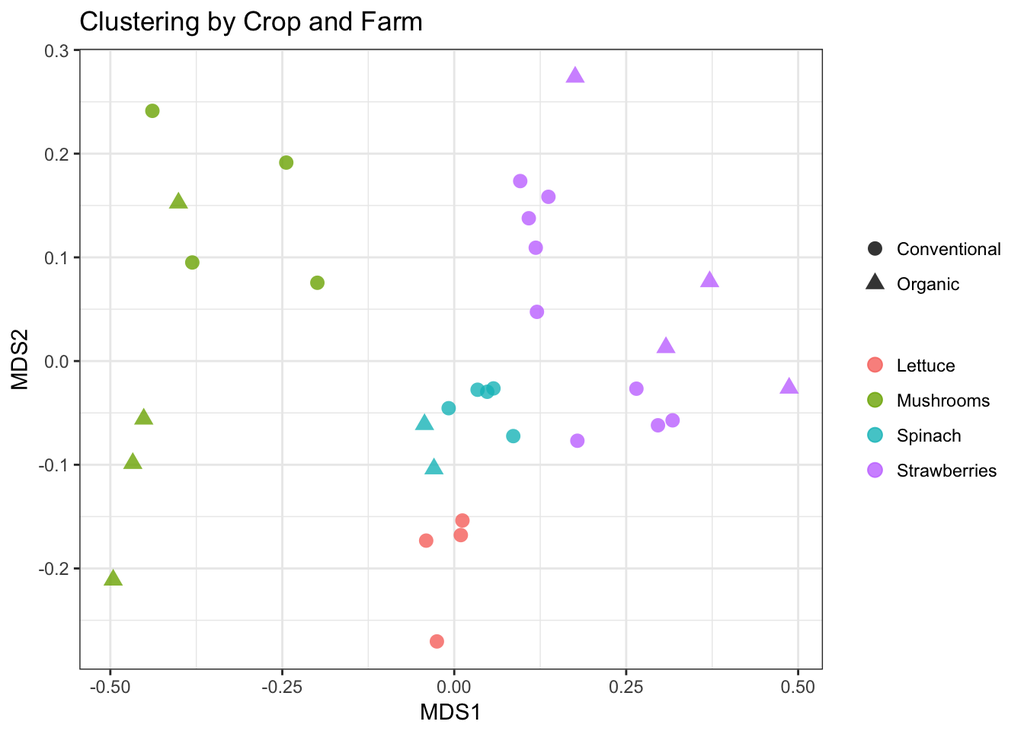

```r
plot_ordination(input = input_rar,
                ordination_axes = ordination,
                color_cat = 'Sample_type',
                shape_cat = "Farm_type")+
  ggtitle("Clustering by Crop and Farm")
```

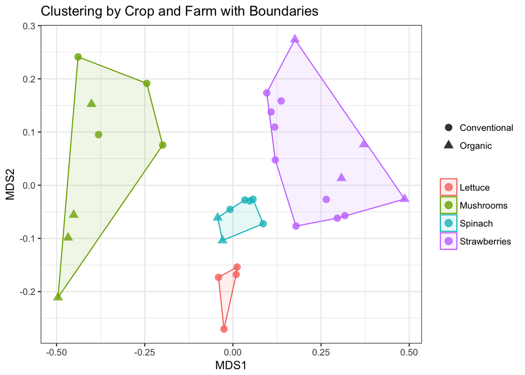

```r
plot_ordination(input=input_rar,
                ordination_axes=ordination,
                color_cat='Sample_type',
                shape_cat = "Farm_type",
                hulls = TRUE) +
  ggtitle("Clustering by Crop and Farm with Boundaries")
```